# Workshop 12 - Your GitHub Profile

Elisabeth Busch-Nentwich

# 1. Introduction

Congratulations on making it to the last workshop of your Coding and Data Science module! You have learnt **A LOT** over the last eleven weeks and now it’s time to show off your skills on your GitHub profile. A well presented profile will impress employers more than a nicely formatted CV. Today we will copy your content from your BIO319 repos into your own GitHub space and use the markdown file format to produce informative README files to guide potential employers through your work.

# 2. Making a GitHub repo

First we’ll make a repo that you will use to store the code and plots from this module. Go to the Repositories tab on your personal GitHub profile and click on the green “new” button.

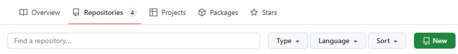

New repo

This brings up a new interface. Here make sure that you are the owner and not “Queen-Mary-University-London-BIO319”. Choose a good repo name, for example you could call it data_viz_portfolio. Then decide whether you want to make it public from the start, or only later when it’s finished. You can leave the other options as they are.

[figure not shown]

repo options

Now you have a new, empty repo. There are different options to start adding files. We’ll go with the simplest, namely uploading them from your computer.

But before we can do that we need to export the data you’d like to show from positCloud. To do this you need to tick the box next to files you’d like to export and then click on the little cog on the top right. Then click *export*.

[figure not shown]

positcloud export

That brings up a prompt where you can name the zip folder positcloud creates from your files.

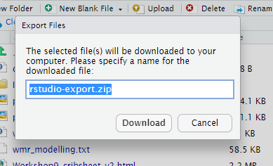

zip folder name

Let’s do just one week for now and then you can add anything else later. Go to one of your workshop projects on positCloud and download the files you would like to put in your repo. The final step is to unzip the folder (if you don’t know how to do that, ask one of us).

We can now go to the repo and upload the files. When you click on the new repo on GitHub you’ll see the following:

[figure not shown]

new repo

Click on **uploading an existing file**. This will bring you to a prompt where you can drag and drop your files.

# 3. A README file

The next step is to add a README file to you repository. If we use the markdown format the file gets interpreted by GitHub and displayed:

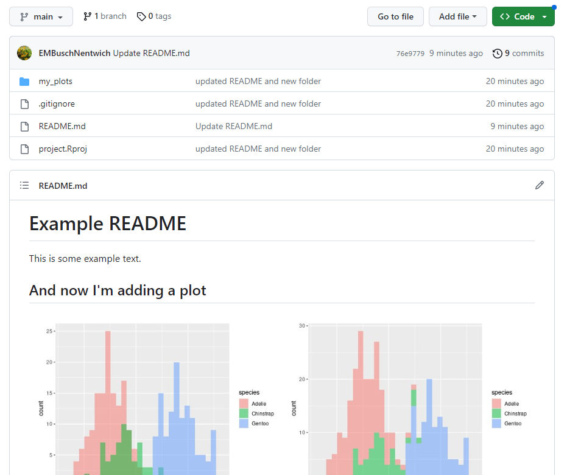

README file on GitHub

I have put the same example README.md file in you workshop together with the my_plots folder.

**Download both and upload them directly on GitHub into your repo by clicking on “Add File”. Now make a positCloud project with your own repo as we’ve been doing for the workshops throughout the weeks and work in that project.**

Open the README.md file and have a look at the format. Compare that to how it is displayed on GitHub. You’ll find that different text types, headers etc are marked by a * or # etc.

Here is another nice example by [Tanya Shapiro](https://github.com/tashapiro/tanya-data-viz). If you click on the README file and then click “raw” on the top right you can see the markdown file.

**Now modify the README file, so that it describes what you have in the repo, shows some of your plots, links to folders, etc. Or you can delete this one and start a new one in your project. Just make sure that you use the “Markdown File” option and call it README. Don’t forget to commit regularly and push when you’re ready to update your repo**

If you would like to display a README on your profile page, you need to make a repo with your user name as the repo name and put the README in there. In fact, when you make that repo and click “Add README” it will come pre-populated with some suggestions what to say.

[figure not shown]

This isn’t really a challenge, but now go ahead and tidy up your projects, and then copy over everything you’d like to keep. You may want to make a folder for each week and then link to them and some example plots in your README. As mentioned above, Tanya Shapiro’s repo is a great example.